# Part 2_R Reference Guid

E. Baylor

12/16/2021

# Part 2: Data Analysis

## Data Exploration

### Numerical Exploration

```r
require(here)
delomys <- read.csv(here("data", "delomys.csv"))
summary(delomys)
```

```
##   observation       genus             binomial           body_mass
##  Min.   :27526   Length:1585        Length:1585        Min.   :  5.00
##  1st Qu.:27950   Class :character   Class :character   1st Qu.: 35.00
##  Median :28348   Mode  :character   Mode  :character   Median : 43.00
##  Mean   :28371                                         Mean   : 44.06
##  3rd Qu.:28790                                         3rd Qu.: 54.00
##  Max.   :35552                                         Max.   :105.00
##   body_length        age                sex              longitude
##  Min.   : 49.0   Length:1585        Length:1585        Min.   :-49681671
##  1st Qu.:106.0   Class :character   Class :character   1st Qu.:      -50
##  Median :116.0   Mode  :character   Mode  :character   Median :      -50
##  Mean   :114.7                                         Mean   :   -62739
##  3rd Qu.:124.0                                         3rd Qu.:      -47
##  Max.   :265.0                                         Max.   :      -41
##     latitude            status
##  Min.   :-22383667   Length:1585
##  1st Qu.:      -29   Class :character
##  Median :      -29   Mode  :character
##  Mean   :   -28272
##  3rd Qu.:      -24
##  Max.   :      -20
```

```r
shapiro.test(delomys$body_mass)
```

```
##
##  Shapiro-Wilk normality test
##
## data:  delomys$body_mass
## W = 0.99506, p-value = 4.33e-05
```

```r
shapiro.test(delomys$body_length)
```

```
##
##  Shapiro-Wilk normality test
##
## data:  delomys$body_length
## W = 0.87609, p-value < 2.2e-16
```

```r
require(palmerpenguins)
```

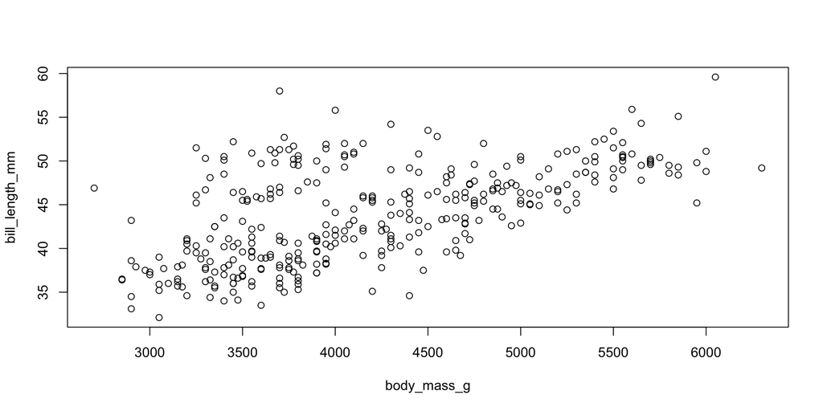

```r
plot(bill_length_mm ~ body_mass_g, data = penguins)
```

### Histogram of Body Mass

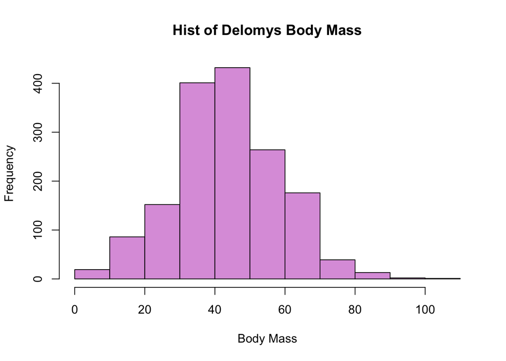

```r
hist(delomys$body_mass, breaks = 10, main = "Hist of Delomys Body Mass", xlab = "Body Mass", col = "#DDA0DD" )
```

### Histogram of Body Length

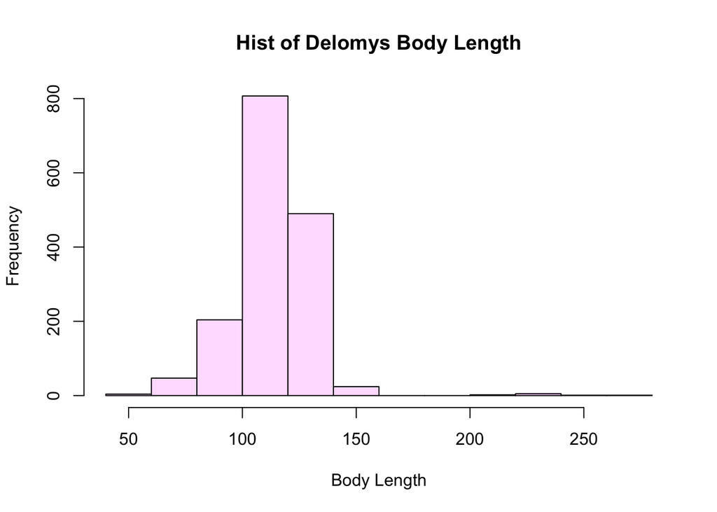

```r
hist(delomys$body_length, breaks = 10, main = "Hist of Delomys Body Length", xlab = "Body Length", col = "#FFE1FF" )
```

### Column Binomial

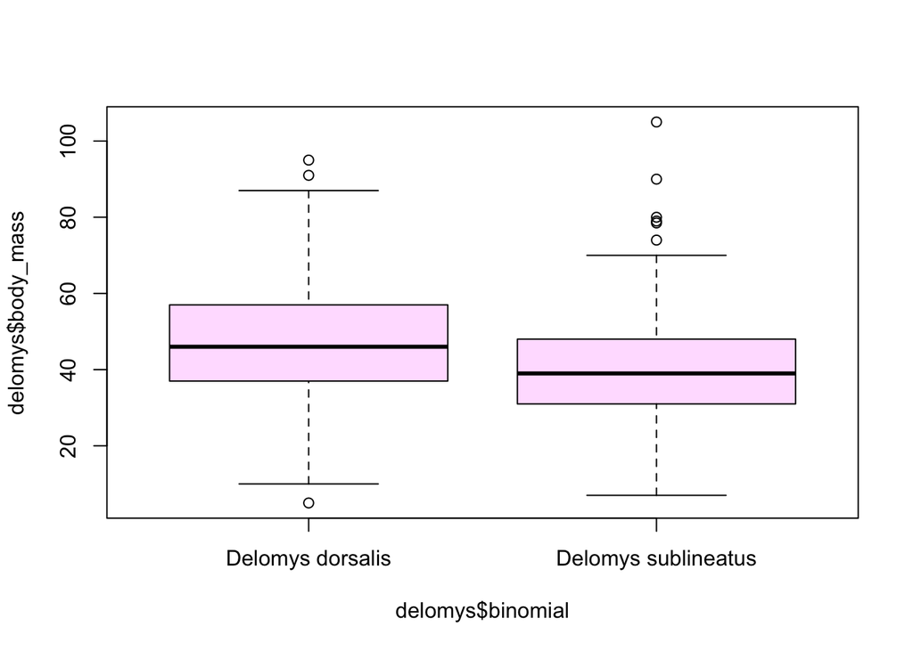

```r
boxplot(delomys$body_mass~delomys$binomial, col = "#FFE1FF")
```

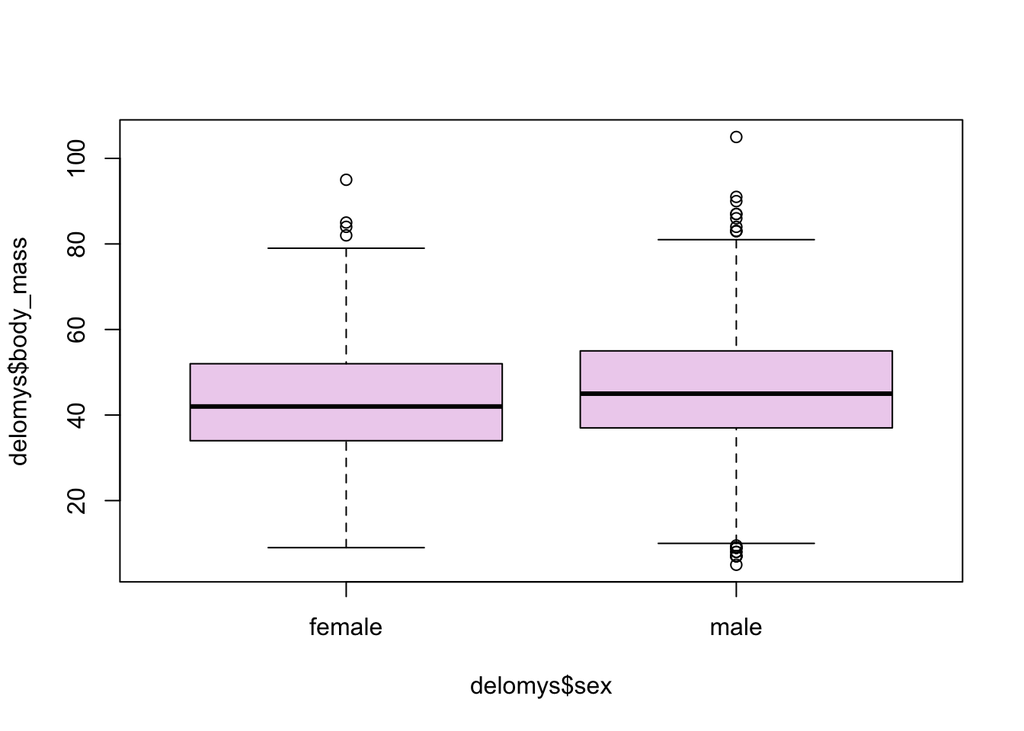

```r
boxplot(delomys$body_mass~delomys$sex, col = "#EED2EE")
```

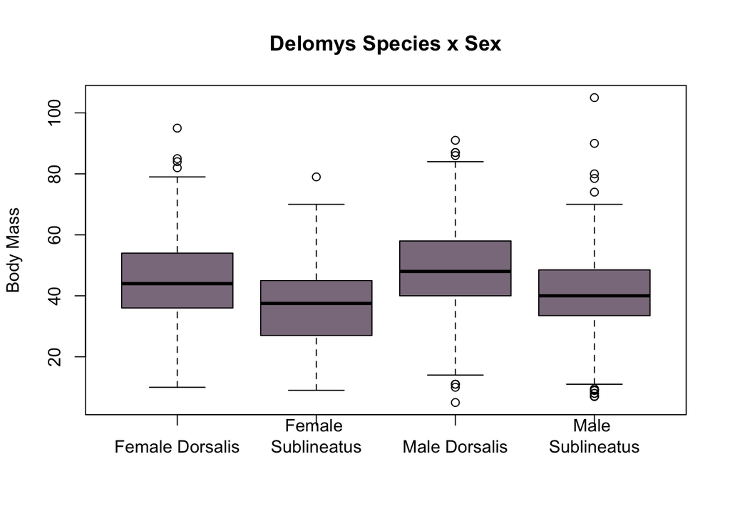

```r
boxplot(delomys$body_mass~delomys$binomial * delomys$sex, col = "#8B7B8B", ylab = "Body Mass", xlab = "", names = c("Female Dorsalis", "Female \nSublineatus", "Male Dorsalis", "Male \nSublineatus"), main = "Delomys Species x Sex")
```

### Question 1

Body mass and body length have a positive linear relationship.

### Question 2

The body mass and body length of Delomys histograms above are both skewed to the right. However, the body length histogram has a longer tail to the right opposed to the body mass histogram.

## Model Building

### Model 1

```r
fit1 = lm(delomys$body_length ~ delomys$body_mass)
```

### Model 2

```r
fit2 = lm(delomys$body_mass ~ delomys$sex)
```

### Model 3

```r
fit3 = lm(delomys$body_mass ~ delomys$binomial)
```

### Model 4

```r
fit4 = lm(delomys$body_mass ~ delomys$sex + delomys$binomial)
```

### Model 5

```r
fit5 = lm(delomys$body_mass ~ delomys$sex * delomys$binomial)
```

## Model Diagnostics

```r
shapiro.test(residuals(fit1))
```

```
##
##  Shapiro-Wilk normality test
##
## data:  residuals(fit1)
## W = 0.73462, p-value < 2.2e-16
```

```r
shapiro.test(residuals(fit2))
```

```
##
##  Shapiro-Wilk normality test
##
## data:  residuals(fit2)
## W = 0.99563, p-value = 0.0001541
```

```r
shapiro.test(residuals(fit3))
```

```
##
##  Shapiro-Wilk normality test
##
## data:  residuals(fit3)
## W = 0.99535, p-value = 8.103e-05
```

```r
shapiro.test(residuals(fit4))
```

```
##
##  Shapiro-Wilk normality test
##
## data:  residuals(fit4)
## W = 0.99525, p-value = 6.805e-05
```

```r
shapiro.test(residuals(fit5))
```

```
##
##  Shapiro-Wilk normality test
##
## data:  residuals(fit5)
## W = 0.99526, p-value = 6.816e-05
```

### Question 6

Violations of the normality assumption are not equally severe for all the models because we there are some explanatory variables that may have implicit factors on them.

## Model Interpretation

```r
knitr::kable(coef(summary(fit1)))
```

|  | Estimate | Std. Error | t value | Pr(>\|t\|) |
| --- | --- | --- | --- | --- |
| (Intercept) | 76.1246565 | 0.9158120 | 83.12258 | 0 |
| delomys$body_mass | 0.8754988 | 0.0196905 | 44.46298 | 0 |

```r
knitr::kable(coef(summary(fit2)))
```

|  | Estimate | Std. Error | t value | Pr(>\|t\|) |
| --- | --- | --- | --- | --- |
| (Intercept) | 42.711465 | 0.5288929 | 80.756355 | 0.0000000 |
| delomys$sexmale | 2.784133 | 0.7456117 | 3.734024 | 0.0001951 |

```r
knitr::kable(coef(summary(fit3)))
```

|  | Estimate | Std. Error | t value | Pr(>\|t\|) |
| --- | --- | --- | --- | --- |
| (Intercept) | 46.752427 | 0.4499933 | 103.89582 | 0 |
| delomys$binomialDelomys sublineatus | -7.683058 | 0.7604562 | -10.10322 | 0 |

```r
knitr::kable(coef(summary(fit4)))
```

[output not shown]

```r
knitr::kable(coef(summary(fit5)))
```

[output not shown]

## Body Length

### Question 7

The p-value of the mass/length relationship is 2.2e-16; therefore, you can reject the null hypothesis between the two variables.

### Question 8

The expected body length of an animal that weighs 100g is 163.6747.

```r
"y= mx + b"
```

```
## [1] "y= mx + b"
```

```r
y = (0.87550)*(100) + (76.12466)
y
```

```
## [1] 163.6747
```

### Question 9

The expected body length of an animal that weighs 0g is 76.12466.

```r
"y= mx + b"
```

```
## [1] "y= mx + b"
```

```r
y = (0.87550)*(0) + (76.12466)
y
```

```
## [1] 76.12466
```

## Model Coefficient

### Question 10

The base level for sex is 42.7115.

### Question 11

The base level for binomial is 46.7524.

### Question 12

Males is the heavier sex.

## Body Mass: ANOVA

```r
knitr::kable(anova(fit1))
```

|  | Df | Sum Sq | Mean Sq | F value | Pr(>F) |
| --- | --- | --- | --- | --- | --- |
| delomys$body_mass | 1 | 269388.9 | 269388.9086 | 1976.957 | 0 |
| Residuals | 1583 | 215706.6 | 136.2645 | NA | NA |

```r
knitr::kable(anova(fit2))
```

|  | Df | Sum Sq | Mean Sq | F value | Pr(>F) |
| --- | --- | --- | --- | --- | --- |
| delomys$sex | 1 | 3061.678 | 3061.6779 | 13.94294 | 0.0001951 |
| Residuals | 1578 | 346507.131 | 219.5863 | NA | NA |

```r
knitr::kable(anova(fit3))
```

|  | Df | Sum Sq | Mean Sq | F value | Pr(>F) |
| --- | --- | --- | --- | --- | --- |
| delomys$binomial | 1 | 21289.68 | 21289.6805 | 102.0751 | 0 |
| Residuals | 1583 | 330164.45 | 208.5688 | NA | NA |

```r
knitr::kable(anova(fit4))
```

[output not shown]

```r
knitr::kable(anova(fit5))
```

[output not shown]

### Question 14

Sex and species are significant predictors for determining the body mass.

### Question 15

There is a significant interaction when because of the p-values, exepts for the factorial interaction between the sex and species.

### Question 16

The significance (as measured by p-value) of either of the main effects (sex and species) differ between the single-predictor models, the additive model and the interactive model by having a significant interaction in the single-predictor and additive models. Oppose to the interactive model where as it is only significant when it is on its own and not when it interacts together.

## Model Comparison: Body Mass

```r
AIC(fit1)
```

```
## [1] 12291.67
```

```r
AIC(fit2)
```

```
## [1] 13006.8
```

```r
AIC(fit3)
```

```
## [1] 12966.36
```

```r
AIC(fit4)
```

```
## [1] 12896.73
```

```r
AIC(fit5)
```

```
## [1] 12898.72
```

### Question 17

Models 1 and 4 have the lowest AIC.

### Question 18

Out of Models 1 and 4, I would choose model 4 to determine the body mass because it compares the sex and binomial oppose to the first model who focuses on the comparison of body mass and length.